# Test Zinb

Jean-Philippe Vert

24 mars 2016

Here we demonstrate the use of ZINB on a toy dataset.

# Standard PCA

Let us first look at the toy data using standard PCA of the log(count+1) matrix

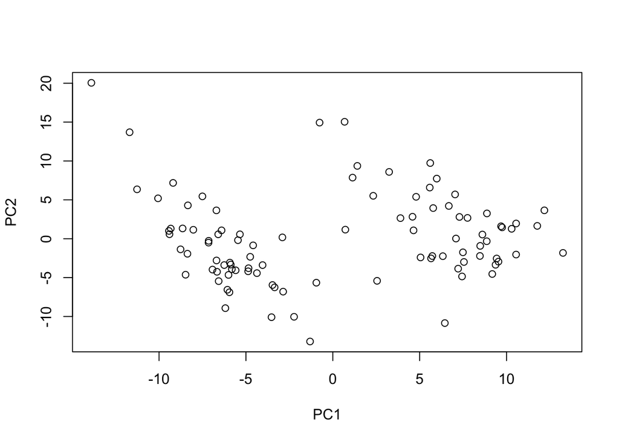

```r
library(zinb)
pc <- prcomp(log(1+toydata),center=TRUE,scale.=TRUE)
plot(pc$x[,1:2])
```

We see two well-separated clusters, mostly separated along the first principal component.

# Original ZINB

Let us now apply ZINB with two factors, and show that the likelihood increases at each iteration (after a small bug correction to make sure this is the case). This is the original function in the functions_svetlana.R file

```r
source("../temporary_files/functions_svetlana.R")
ptm <- proc.time()
z <- zinb(toydata, alt.number=10)
```

```
## [1] 1
## [1] -4016619
## [1] -356561
## [1] 2
## [1] -338283.7
## [1] -314369.3
## [1] 3
## [1] -285116.3
## [1] -221012.5
## [1] 4
## [1] -211326
## [1] -203059.3
## [1] 5
## [1] -202579.1
## [1] -202360.9
## [1] 6
## [1] -202273
## [1] -202182.4
## [1] 7
## [1] -202118
## [1] -202058.4
## [1] 8
## [1] -202004
## [1] -201954
## [1] 9
## [1] -201908.5
## [1] -201865
## [1] 10
## [1] -201821.3
## [1] -201778.8
```

```r
print(proc.time()-ptm)
```

```
##    user  system elapsed
## 327.970  97.671 428.936
```

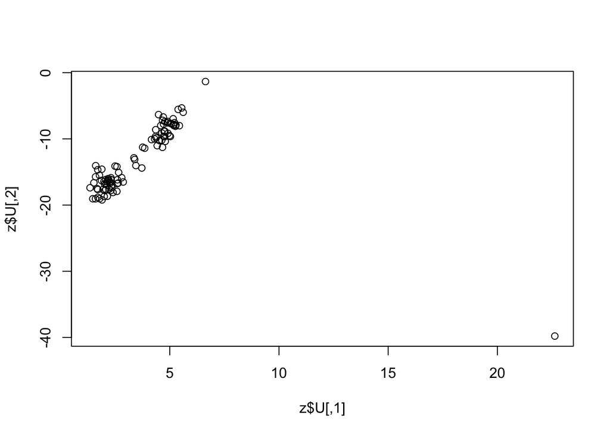

```r
plot(z$U)
```

We have to wait a few minutes, and there is a strange outlier in the final picture.

# ZINB v2: faster and numerically more stable

We wrote a faster and hopefully more stable version. The main changes compared to the original zinb are:

- only one row/column of the count matrix is passed to the likelihood function and its gradient (this is what makes the speed-up)
- the computation of the likelihood and its gradient have been modified to reduce the impact of numerical errors; this prevents the divergence of some of the coefficients whose likelihood could not get very small because of numerical errors in the original version.

```r
ptm <- proc.time()
z2 <- zinb2(toydata, alt.number=10)
```

```
## Iteration 1
## log-likelihood = -3895001
##    user  system elapsed
##   8.004   0.735   8.776
## log-likelihood = -323307.6
## Iteration 2
## log-likelihood = -302980
##    user  system elapsed
##   7.915   0.766   8.798
## log-likelihood = -211878.9
## Iteration 3
## log-likelihood = -203973.4
##    user  system elapsed
##   5.142   0.484   5.658
## log-likelihood = -197545.5
## Iteration 4
## log-likelihood = -197034.5
##    user  system elapsed
##   3.667   0.337   4.025
## log-likelihood = -196859.1
## Iteration 5
## log-likelihood = -196821.8
##    user  system elapsed
##   3.409   0.312   3.743
## log-likelihood = -196794.5
## Iteration 6
## log-likelihood = -196782.1
##    user  system elapsed
##   3.328   0.305   3.655
## log-likelihood = -196768.6
## Iteration 7
## log-likelihood = -196761.4
##    user  system elapsed
##   3.173   0.295   3.482
## log-likelihood = -196754.2
## Iteration 8
## log-likelihood = -196749.3
##    user  system elapsed
##   3.105   0.290   3.408
## log-likelihood = -196743.6
## Iteration 9
## log-likelihood = -196740
##    user  system elapsed
##   3.129   0.289   3.439
## log-likelihood = -196735.7
## Iteration 10
## log-likelihood = -196732.9
##    user  system elapsed
##   3.231   0.297   3.564
## log-likelihood = -196725.8
```

```r
print(proc.time()-ptm)
```

```
##    user  system elapsed
##  68.672   9.562  78.764
```

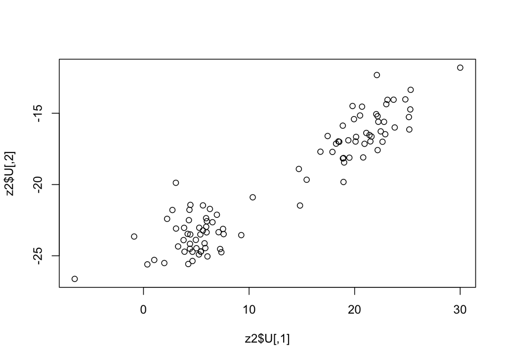

```r
plot(z2$U)
```

# ZINB v3 : faster, more stable, and ready for more general regression

We made a new version, again slightly faster, hopefully more stable, and more importantly ready to be used for the general regression framework with various covariates (which is the main motivation to rewrite a new function). Compared to the previous one:

- the two likelihood and gradient functions (one for the left optimization, one for the right optimization) have been merged onto a single function that can be called with various arguments
- the function can perform not only PCA, but the more general regression settings with covariates and offsets
- the gradient of the likelihood has been improved for numerical stability
- unnecessary computations have been removed in the computation of the gradient and its likelihood (which leads to a small speed up).
- the main embarassingly parallel loop has been parallelized

Let us first check it withough parallelization

```r
ptm <- proc.time()
z3 <- zinb.PCA(toydata, alt.number=10, verbose=TRUE, no_cores=1)
```

```
## Iteration 1
## log-likelihood = -3895001
##    user  system elapsed
##   9.434   0.846  10.354
## log-likelihood = -323308.1
##    user  system elapsed
##   0.779   0.039   0.822
## Iteration 2
## log-likelihood = -303575.1
##    user  system elapsed
##   8.278   0.718   9.053
## log-likelihood = -209783.1
##    user  system elapsed
##   0.908   0.031   0.943
## Iteration 3
## log-likelihood = -203147.8
##    user  system elapsed
##   5.962   0.501   6.500
## log-likelihood = -197594.6
##    user  system elapsed
##   0.705   0.023   0.730
## Iteration 4
## log-likelihood = -197097.1
##    user  system elapsed
##   3.954   0.329   4.302
## log-likelihood = -196886.4
##    user  system elapsed
##   0.716   0.029   0.747
## Iteration 5
## log-likelihood = -196860.9
##    user  system elapsed
##   3.648   0.304   3.966
## log-likelihood = -196825.3
##    user  system elapsed
##   0.728   0.021   0.751
## Iteration 6
## log-likelihood = -196828.4
##    user  system elapsed
##   3.707   0.307   4.032
## log-likelihood = -196797.6
##    user  system elapsed
##   0.757   0.021   0.787
## Iteration 7
## log-likelihood = -196804.6
##    user  system elapsed
##   3.593   0.299   3.912
## log-likelihood = -196786.8
##    user  system elapsed
##   0.719   0.015   0.739
## Iteration 8
## log-likelihood = -196795.9
```

```r
print(proc.time()-ptm)
```

```
##    user  system elapsed
##  44.209   3.521  48.002
```

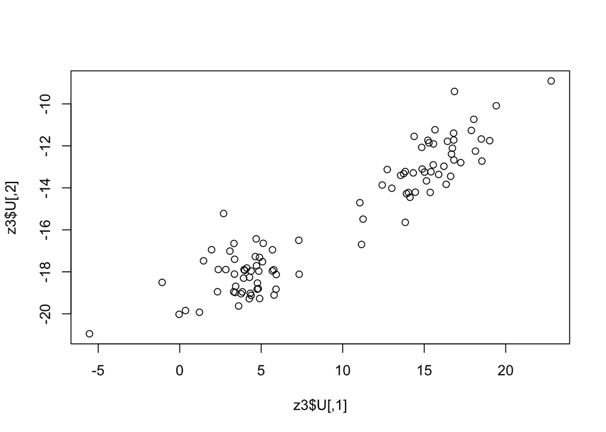

```r
plot(z3$U)
```

```r
ptm <- proc.time()
z4 <- zinb.PCA(toydata, alt.number=10, verbose=TRUE, no_cores=3)
```

```
## Iteration 1
## log-likelihood = -3895001
##    user  system elapsed
##   4.599   0.456   5.300
## log-likelihood = -323308.1
##    user  system elapsed
##   9.725   1.070   0.751
## Iteration 2
## log-likelihood = -303575.1
##    user  system elapsed
##  10.318   1.311   5.580
## log-likelihood = -209783.1
##    user  system elapsed
##   5.785   0.863   0.870
## Iteration 3
## log-likelihood = -203147.8
##    user  system elapsed
##   6.217   0.579   3.402
## log-likelihood = -197594.6
##    user  system elapsed
##   3.681   0.287   0.398
## Iteration 4
## log-likelihood = -197097.1
##    user  system elapsed
##   4.137   0.308   2.181
## log-likelihood = -196886.4
##    user  system elapsed
##   2.658   0.224   0.425
## Iteration 5
## log-likelihood = -196860.9
##    user  system elapsed
##   2.270   0.300   2.277
## log-likelihood = -196825.3
##    user  system elapsed
##   4.253   0.555   0.432
## Iteration 6
## log-likelihood = -196828.4
##    user  system elapsed
##   4.466   0.590   2.239
## log-likelihood = -196797.6
##    user  system elapsed
##   2.912   0.619   0.726
## Iteration 7
## log-likelihood = -196804.6
##    user  system elapsed
##   2.206   0.304   1.884
## log-likelihood = -196786.8
##    user  system elapsed
##   4.023   0.344   0.420
## Iteration 8
## log-likelihood = -196795.9
```

```r
print(proc.time()-ptm)
```

```
##    user  system elapsed
##  67.953   8.063  27.856
```

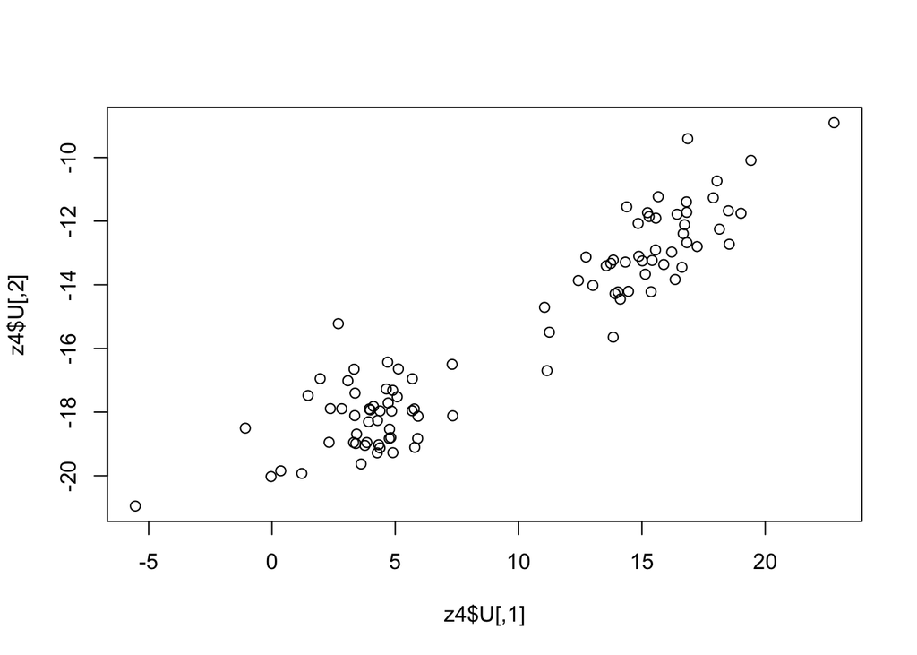

```r
plot(z4$U)
```

Note that if we do not optimize over theta, whose gradient is the most expensive to compute, we should get further speed-up. The last version does that for free, it suffices to change the arguments of the optimization function (TODO…)